# Case Study 1: College Basketball

## Comparing multiple means (Analysis of Variance)

What if we want to compare more than one team? In lecture, you learned about using an Analysis of Variance (ANOVA) F-test to check if more than two means are equal. We will use the function `aov( )` to find out if the big three North Carolina teams - UNC, Duke, and NC State - all tend to score the same number of points.

### Question 10

1. Make a dataset called `nc_games` that includes only games for the North Carolina teams, and then alter the code below to create a box plot of the scores for the three North Carolina teams. Does it look like any of the means are significantly different?

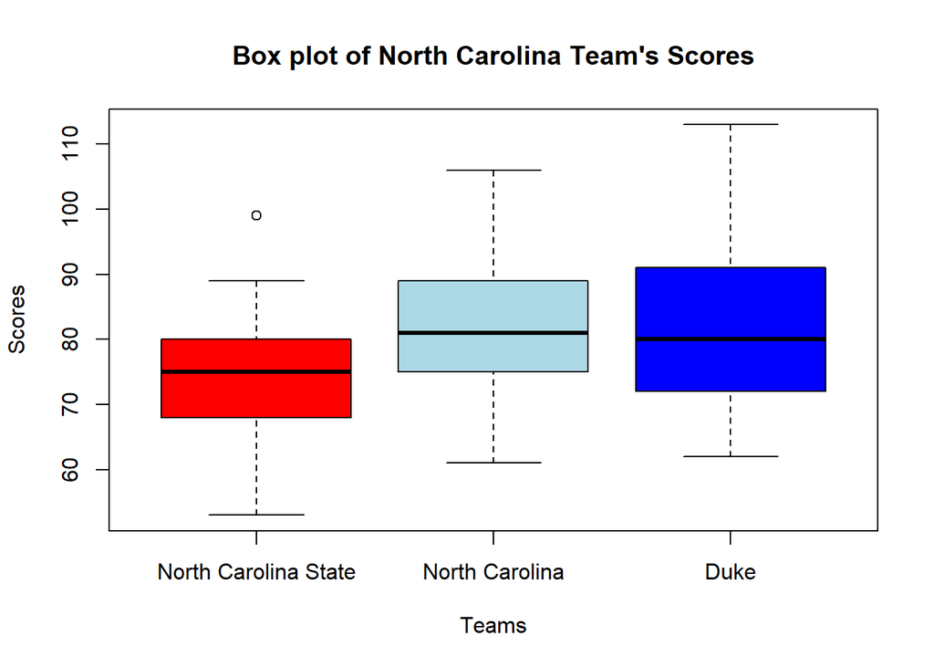

```r
nc_games = bball[bball$Team =="North Carolina State",]
unc_games = bball[bball$Team == "North Carolina",]
duke_games = bball[bball$Team == "Duke",]
names <- c("North Carolina State", "North Carolina", "Duke")

boxplot(nc_games$Team.Score,unc_games$Team.Score,duke_games$Team.Score, names = names,xlab ="Teams",ylab = "Scores", main = "Box plot of North Carolina Team's Scores", col = c("red", "lightblue","blue"))
```

```r
"Based on the boxplots, the Mean score of NC State is much lower than UNC and Duke's Scores. UNC and Duke have similar mean scores but UNC is slightly higher"
```

```
## [1] "Based on the boxplots, the Mean score of NC State is much lower than UNC and Duke's Scores. UNC and Duke have similar mean scores but UNC is slightly higher"
```

2. Perform an ANOVA F-test on the means. Interpret the output. Is there evidence that the average scores of the three teams are not all equal?

```r
all_teams = bball[bball$Team =="North Carolina State" | bball$Team == "North Carolina" | bball$Team == "Duke",]
anova=aov(all_teams$Team.Score~all_teams$Team)

summary(anova)
```

```
##                Df Sum Sq Mean Sq F value Pr(>F)
## all_teams$Team  2    990   494.9   3.697 0.0284 *
## Residuals      97  12986   133.9
## ---
## Signif. codes:  0 '***' 0.001 '**' 0.01 '*' 0.05 '.' 0.1 ' ' 1
```

```r
"Based on the p-value of the data(0.0284), the p-value is significant enough to reject the null. We can then conclude that the average scores of at least one of the three teams are not equal"
```

```
## [1] "Based on the p-value of the data(0.0284), the p-value is significant enough to reject the null. We can then conclude that the average scores of at least one of the three teams are not equal"
```